# Analysis_two_classes slides

## DYLEMAT STUDENTA

## WINO WYTRAWNE CZY WINO TANIE I OBIAD ?

### a. wyznaczanie jakosci wina na podstawie parametrow cieczy

### b. aplikacja dla urzedu kontrolujacego winiarnie

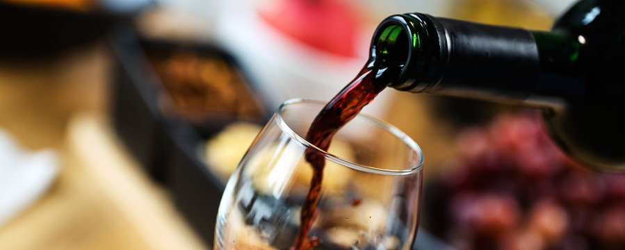

This study consider *vinho verde*, a unique product from the Minho (north-west) region of Portugal.

The data were collected from May/2004 to February/2007

Each sample was evaluated by a minimum of three sensory assessors (using blindtastes), which graded the wine in a scale that ranges from 1 (very bad) to 10 (excellent). The final sensory score is given by the median of these evaluations.

```
<class 'pandas.core.frame.DataFrame'>
RangeIndex: 1599 entries, 0 to 1598
Data columns (total 12 columns):
 #   Column                Non-Null Count  Dtype
---  ------                --------------  -----
 0   fixed acidity         1599 non-null   float64
 1   volatile acidity      1599 non-null   float64
 2   citric acid           1599 non-null   float64
 3   residual sugar        1599 non-null   float64
 4   chlorides             1599 non-null   float64
 5   free sulfur dioxide   1599 non-null   float64
 6   total sulfur dioxide  1599 non-null   float64
 7   density               1599 non-null   float64
 8   pH                    1599 non-null   float64
 9   sulphates             1599 non-null   float64
 10  alcohol               1599 non-null   float64
 11  quality               1599 non-null   int64
dtypes: float64(11), int64(1)
memory usage: 150.0 KB
```

#### Checking the share of individual categories

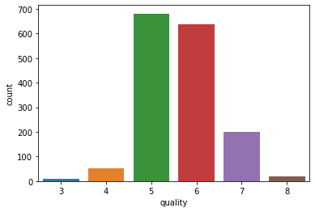

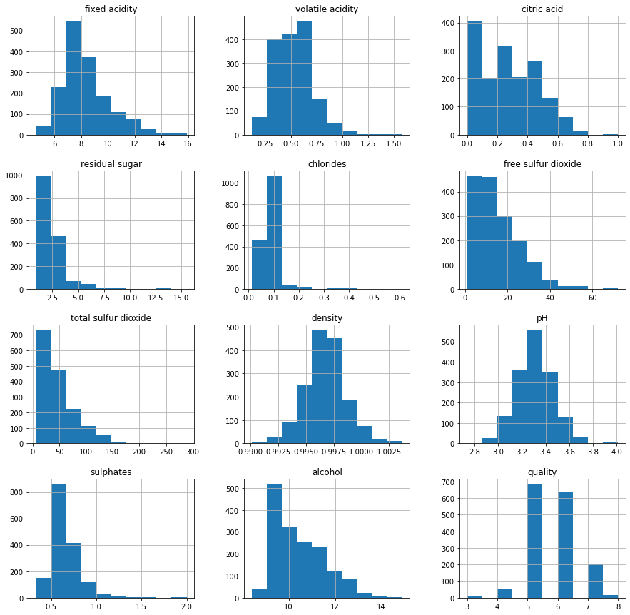

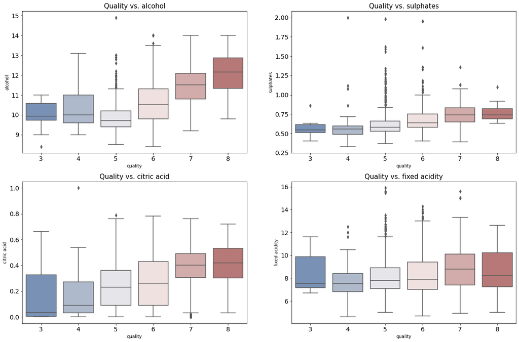

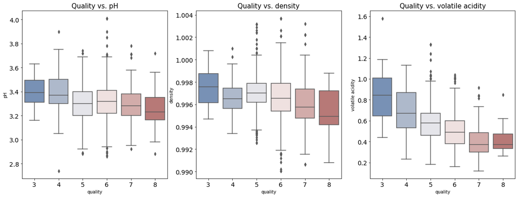

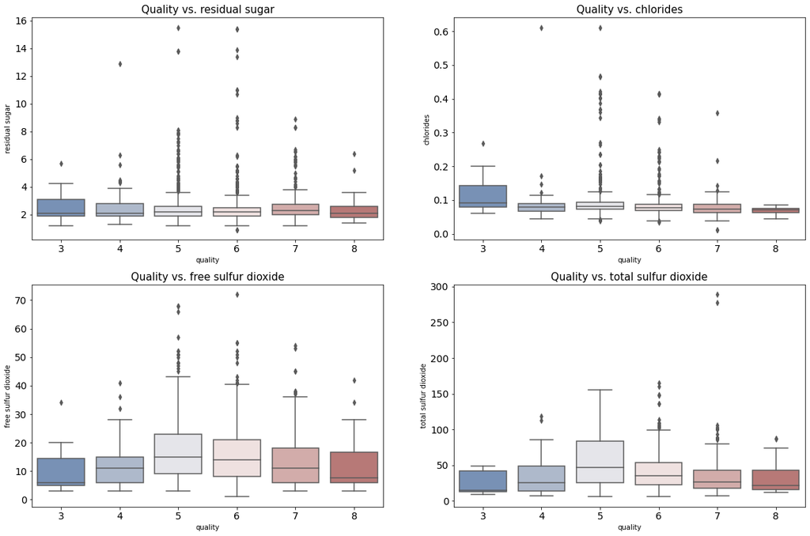

### Changing the target into two categories

#### Przeliczenie ze skali Parkera na skalę zastosowaną w zestawie danych

Klasa 10 – 96 do 100 punktów, są to wina idealne, o głębi nieporównywalnej z niczym oraz spełniające wszystkie nasze oczekiwania.

Klasa 9 – 90 do 95 punktów, to wina doskonałe, skomplikowane i o niezwykłym charakterze.

Klasa 7, 8 – 80 do 89 punktów, mieszczą się tu wina dobre, niczym nie zaburzone, posiadające własny styl i finezję.

Klasa 5, 6 – 70 do 79 punktów, jest to kategoria dla win przeciętnych, w żaden sposób nie wyróżniających się, jednak zrobionych poprawnie.

Klasa 3, 4 – 60 do 69 punktów, są to wina złe obdarzone licznymi wadami, takimi jak nadmierna kwasowość, taniczność, słodycz, lub brak jakiegokolwiek aromatu.

Klasa 1, 2 – 50 do 59 punktów, to wina nie nadające się do konsumpcji.

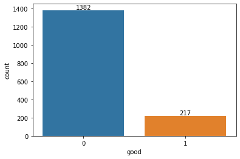

### Tested models:

- Logistic Regression
- RandomForest
- XgBoost
- GaussianNB
- KNearestNeighbours
- AdaBoost
- SVC

## Feature Engineering

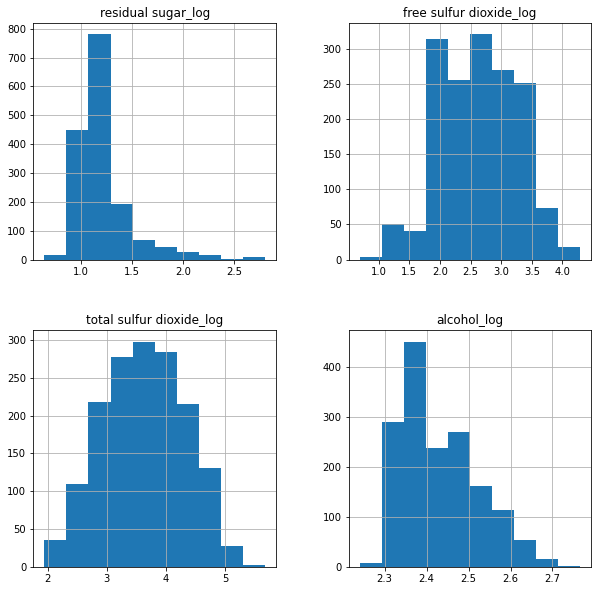

## Oversampling

### sampling strategy=0.5

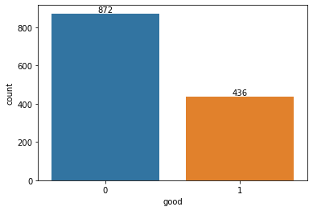

### sampling strategy=0.75

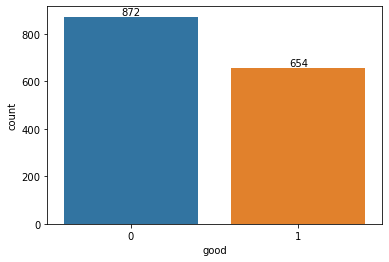

### sampling strategy=1.0

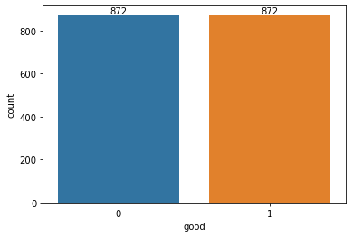

|  | Model | fbeta_cv | recall dla 0 | recall dla 1 |
| --- | --- | --- | --- | --- |
| 0 | ('LogisticRegression', 'X_train') | 0.879169 | 0.966819 | 0.382979 |
| 1 | ('LogisticRegression', 'X_train po FE') | 0.878606 | 0.972477 | 0.414286 |
| 2 | ('LogisticRegression', 'X_train_0.5') | 0.830334 | 0.870413 | 0.770642 |
| 3 | ('LogisticRegression', 'X_train_0.75') | 0.824877 | 0.826835 | 0.830275 |
| 4 | ('LogisticRegression', 'X_train_1.0') | 0.830367 | 0.805046 | 0.869266 |
| 5 | ('RandomForestClassifier', 'X_train') | 0.896035 | 1.000000 | 1.000000 |
| 6 | ('RandomForestClassifier', 'X_train po FE') | 0.904924 | 1.000000 | 1.000000 |
| 7 | ('RandomForestClassifier', 'X_train_0.5') | 0.918147 | 1.000000 | 1.000000 |
| 8 | ('RandomForestClassifier', 'X_train_0.75') | 0.929138 | 1.000000 | 1.000000 |
| 9 | ('RandomForestClassifier', 'X_train_1.0') | 0.933703 | 1.000000 | 1.000000 |
| 10 | ('XGBClassifier', 'X_train') | 0.896430 | 1.000000 | 1.000000 |
| 11 | ('XGBClassifier', 'X_train po FE') | 0.891375 | 1.000000 | 1.000000 |
| 12 | ('XGBClassifier', 'X_train_0.5') | 0.918163 | 1.000000 | 1.000000 |
| 13 | ('XGBClassifier', 'X_train_0.75') | 0.924605 | 1.000000 | 1.000000 |
| 14 | ('XGBClassifier', 'X_train_1.0') | 0.934435 | 1.000000 | 1.000000 |
| 15 | ('GaussianNB', 'X_train') | 0.855292 | 0.882151 | 0.702128 |
| 16 | ('GaussianNB', 'X_train po FE') | 0.839361 | 0.862385 | 0.721429 |
| 17 | ('GaussianNB', 'X_train_0.5') | 0.818993 | 0.825688 | 0.814220 |
| 18 | ('GaussianNB', 'X_train_0.75') | 0.809146 | 0.809633 | 0.814985 |
| 19 | ('GaussianNB', 'X_train_1.0') | 0.808189 | 0.802752 | 0.821101 |
| 20 | ('KNeighborsClassifier', 'X_train') | 0.868385 | 0.958810 | 0.574468 |
| 21 | ('KNeighborsClassifier', 'X_train po FE') | 0.869898 | 0.958716 | 0.607143 |
| 22 | ('KNeighborsClassifier', 'X_train_0.5') | 0.867621 | 0.883028 | 0.974771 |
| 23 | ('KNeighborsClassifier', 'X_train_0.75') | 0.867847 | 0.855505 | 0.998471 |
| 24 | ('KNeighborsClassifier', 'X_train_1.0') | 0.879107 | 0.846330 | 1.000000 |
| 25 | ('AdaBoostClassifier', 'X_train') | 0.870304 | 0.977117 | 0.553191 |
| 26 | ('AdaBoostClassifier', 'X_train po FE') | 0.878494 | 0.971330 | 0.521429 |
| 27 | ('AdaBoostClassifier', 'X_train_0.5') | 0.860441 | 0.925459 | 0.857798 |
| 28 | ('AdaBoostClassifier', 'X_train_0.75') | 0.859086 | 0.895642 | 0.905199 |
| 29 | ('AdaBoostClassifier', 'X_train_1.0') | 0.863852 | 0.872706 | 0.923165 |
| 30 | ('SVC', 'X_train') | 0.880095 | 0.988558 | 0.397163 |
| 31 | ('SVC', 'X_train po FE') | 0.875664 | 0.986239 | 0.428571 |
| 32 | ('SVC', 'X_train_0.5') | 0.873550 | 0.940367 | 0.844037 |
| 33 | ('SVC', 'X_train_0.75') | 0.877435 | 0.913991 | 0.900612 |
| 34 | ('SVC', 'X_train_1.0') | 0.884654 | 0.911697 | 0.923165 |

#### Oversampling effect

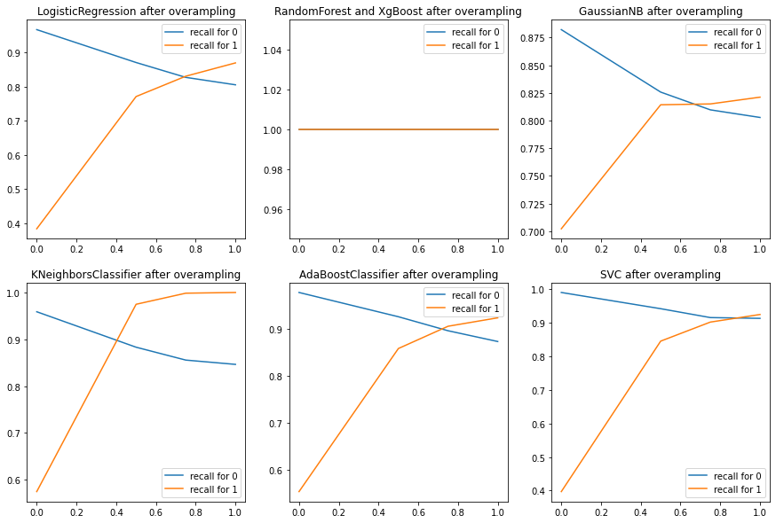

### RandomForest

```
Training set
fbeta_score:  0.9821895592540417
roc_auc_score:  0.9994318660045451

Classification report:
               precision    recall  f1-score   support

           0       0.99      0.97      0.98       872
           1       0.97      0.99      0.98       872

    accuracy                           0.98      1744
   macro avg       0.98      0.98      0.98      1744
weighted avg       0.98      0.98      0.98      1744
```

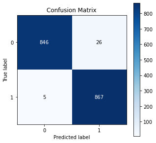

```
Test set
fbeta_score:  0.888750874665143
roc_auc_score:  0.913458110516934

Classification report:
               precision    recall  f1-score   support

           0       0.95      0.91      0.93       374
           1       0.57      0.72      0.64        60

    accuracy                           0.89       434
   macro avg       0.76      0.82      0.79       434
weighted avg       0.90      0.89      0.89       434
```

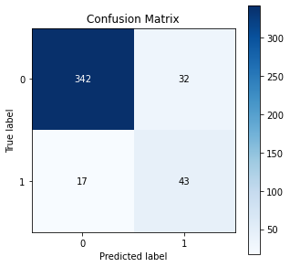

### XgBoost

```
Training set
fbeta_score:  1.0
roc_auc_score:  1.0

Classification report:
               precision    recall  f1-score   support

           0       1.00      1.00      1.00       872
           1       1.00      1.00      1.00       872

    accuracy                           1.00      1744
   macro avg       1.00      1.00      1.00      1744
weighted avg       1.00      1.00      1.00      1744
```

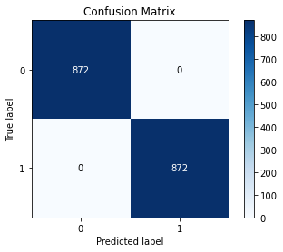

```
Test set
fbeta_score:  0.8894009216589863
roc_auc_score:  0.8848039215686275

Classification report:
               precision    recall  f1-score   support

           0       0.94      0.94      0.94       374
           1       0.60      0.60      0.60        60

    accuracy                           0.89       434
   macro avg       0.77      0.77      0.77       434
weighted avg       0.89      0.89      0.89       434
```

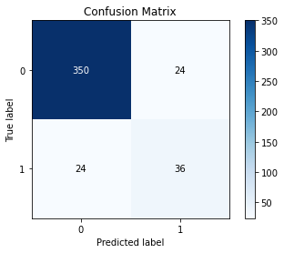

### Removal of low importance features acording Random Forest

```
fbeta_score:  0.8867566010711172
roc_auc_score:  0.8950089126559715

Classification report:
               precision    recall  f1-score   support

           0       0.96      0.91      0.93       374
           1       0.56      0.75      0.64        60

    accuracy                           0.88       434
   macro avg       0.76      0.83      0.79       434
weighted avg       0.90      0.88      0.89       434
```

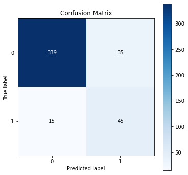

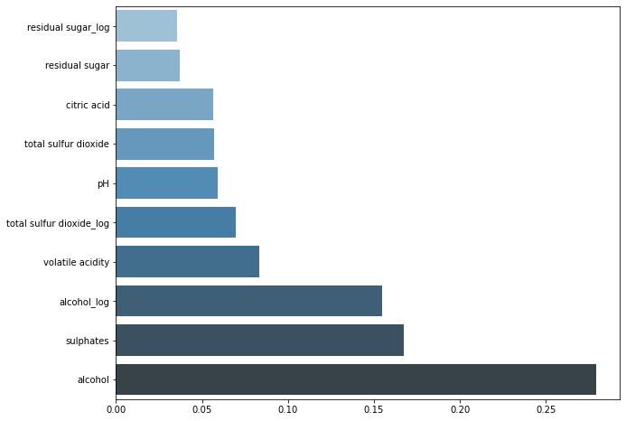

```
roc_auc_score:  0.8950089126559715
```

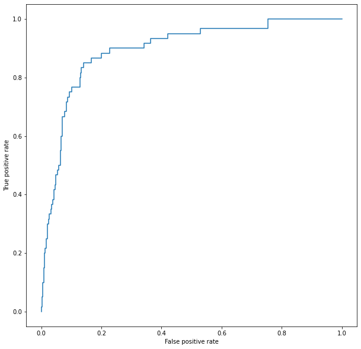